# Tutorial: Importação online de séries temporais econômicas e financeiras usando R

Marcelo S. Perlin

2019-09-03

# Antes de começar

Acesse o link abaixo e deixe o seu email para envio do material.

https://tinyurl.com/este-2019

# Quem sou eu?

Professor de graduação e pós-graduação da EA e pesquisador acadêmico.

**Interesses**

Mercados e dados financeiros, cientometria, programação em R

**Contato**

marceloperlin@gmail.com

**Página pessoal com código/artigos/blog**

https://www.msperlin.com/

**Livro padfeR**

Disponível na [Amazon](https://www.amazon.com.br/dp/B07DN4M357). Versão online e gratuita (até cap 6) no [site](https://www.msperlin.com/padfeR/).

[figure not shown]

# Sobre o Tutorial

**Tutorial prático sobre a importação de dados de séries econômicas e financeiras com a plataforma R.**

**Um exemplo do ciclo de pesquisa será dado no final do tutorial.**

# O que é o R

**Definição**

O R é uma linguagem de programação voltada para a resolução de problemas estatísticos e para a visualização gráfica de dados.

**Autores**

Ross Ihaka e Robert Gentleman (*The University of Auckland*)

**Funcionalidade**

R é sinônimo de programação voltada à análise de dados

**Custo**

**o R é totalmente livre** e disponível em vários sistemas operacionais.

# Por que Escolher o R

- R é uma plataforma madura, estável, continuamente suportada e intensamente utilizada na indústria.
- Aprender a linguagem do R é fácil.
- A interface do R e RStudio torna o uso da ferramenta bastante produtivo.
- Os pacotes do R permitem as mais diversas funcionalidades.
- O R tem compatibilidade com diferentes linguagens e sistemas operacionais.
- O R é totalmente gratuito!

# Introdução

**Por que baixar dados diretos na sessão do R?**

- Eficiência na administração de dados no ciclo da pesquisa: **dados brutos -> limpeza -> teste de hipóteses -> relatório**;
- Confiabilidade: muitos dados financeiros são coletados “direto da fonte”;
- Reproducibilidade da pesquisa: qualquer um que rodar o código terá sempre os mesmos dados

# Panorama

**BatchGetSymbols**

Dados de preços diários de ações direto do Yahoo finance.

**GetBCBData**

Dados do sistema SGS do banco central brasileiro. Diversas séries econômicas regionais e nacionais.

**GetHFData**

Dados de transações e ordens financeiras nos mercados da B3 (ações e derivativos).

**GetDFPData**

Dados dos sistema DFP, FRE e FCA da B3. Demostrativos financeiros anuais e outras informações.

**GetTDData**

Dados do Tesouro Direto (títulos públicos). Preços e yields de contratos de dívida soberana.

# Pacote `BatchGetSymbols`

**Descrição**

Obtenção de dados diários de preços e volume negociados para ações em larga escala

**Fonte**

Yahoo Finance

**Benefícios**

- Limpeza e organização;
- Controle de erros de importação;
- Comparação de datas a um *benchmark*;
- Uso de sistema local de cache (pedidos repetidos de dados são importados localmente);
- Computação paralela: Usuários podem usar todos os núcleos (processadores) para pedir dados;
- Acesso a *tickers* em índices de mercado;
- Flexibilidade de formato de saída: longo (empilhado) ou wide (indexado por colunas);

## Exemplo 1: EGIE3

```r
library(BatchGetSymbols)
library(tidyverse)

ticker <- 'EGIE3.SA'
first.date <- Sys.Date() - 365
last.date <- Sys.Date()


l_out <- BatchGetSymbols(tickers = ticker,
                         first.date = first.date,
                         last.date = last.date)

glimpse(l_out)
```

```
## List of 2
##  $ df.control:Classes 'tbl_df', 'tbl' and 'data.frame':  1 obs. of  6 variables:
##   ..$ ticker              : chr "EGIE3.SA"
##   ..$ src                 : chr "yahoo"
##   ..$ download.status     : chr "OK"
##   ..$ total.obs           : int 245
##   ..$ perc.benchmark.dates: num 0.948
##   ..$ threshold.decision  : chr "KEEP"
##  $ df.tickers:'data.frame':  245 obs. of  10 variables:
##   ..$ price.open         : num [1:245] 29.2 29.7 29.1 29.3 29.8 ...
##   ..$ price.high         : num [1:245] 30.1 29.8 29.4 29.8 29.9 ...
##   ..$ price.low          : num [1:245] 29.2 29 29 29.1 29.4 ...
##   ..$ price.close        : num [1:245] 29.6 29.1 29.1 29.6 29.5 ...
##   ..$ volume             : num [1:245] 1489750 1326500 678500 1056000 743125 ...
##   ..$ price.adjusted     : num [1:245] 27.9 27.4 27.3 27.8 27.8 ...
##   ..$ ref.date           : Date[1:245], format: "2018-09-03" ...
##   ..$ ticker             : chr [1:245] "EGIE3.SA" "EGIE3.SA" "EGIE3.SA" "EGIE3.SA" ...
##   ..$ ret.adjusted.prices: num [1:245] NA -0.017279 -0.001648 0.017061 -0.000812 ...
##   ..$ ret.closing.prices : num [1:245] NA -0.017279 -0.001648 0.017061 -0.000812 ...
```

```r
glimpse(l_out$df.tickers)
```

```
## Observations: 245
## Variables: 10
## $ price.open          <dbl> 29.240, 29.656, 29.112, 29.328, 29.824, 29.2…
## $ price.high          <dbl> 30.064, 29.784, 29.368, 29.824, 29.904, 29.4…
## $ price.low           <dbl> 29.240, 29.024, 29.008, 29.136, 29.360, 29.0…
## $ price.close         <dbl> 29.632, 29.120, 29.072, 29.568, 29.544, 29.2…
## $ volume              <dbl> 1489750, 1326500, 678500, 1056000, 743125, 7…
## $ price.adjusted      <dbl> 27.86162, 27.38021, 27.33507, 27.80144, 27.7…
## $ ref.date            <date> 2018-09-03, 2018-09-04, 2018-09-05, 2018-09…
## $ ticker              <chr> "EGIE3.SA", "EGIE3.SA", "EGIE3.SA", "EGIE3.S…
## $ ret.adjusted.prices <dbl> NA, -0.0172786448, -0.0016483440, 0.01706115…
## $ ret.closing.prices  <dbl> NA, -0.0172785840, -0.0016483516, 0.01706108…
```

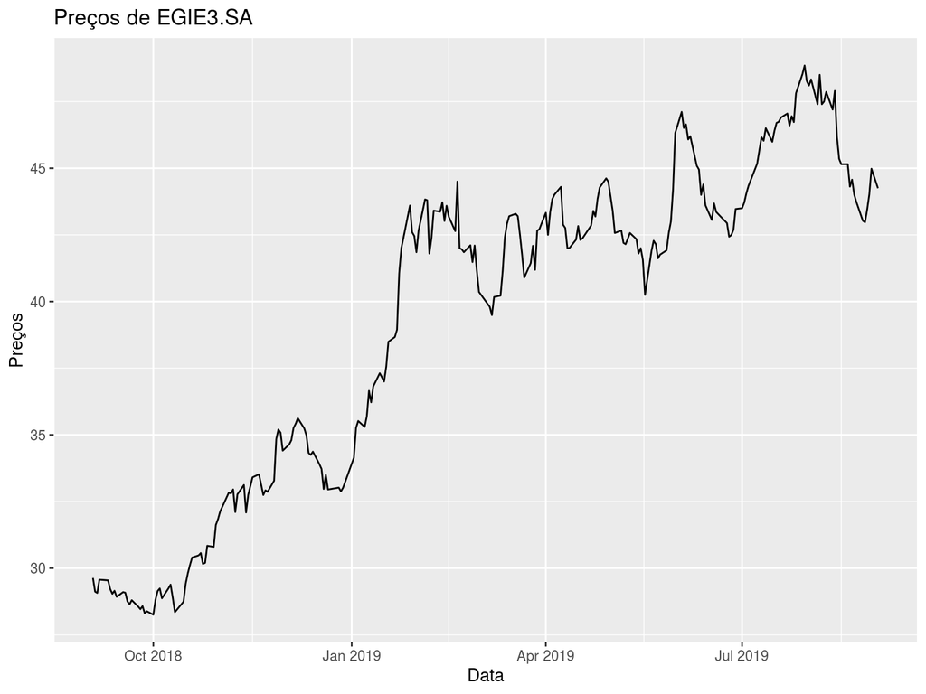

```r
df.prices <- l_out$df.tickers

p <- ggplot(df.prices, aes(x = ref.date, y = price.close)) +
  geom_line() +
  labs(title = paste0('Preços de ', ticker),
       x = 'Data',
       y = 'Preços')

print(p)
```

## Exemplo 2: Composição do Ibovespa

```r
df.ibov <- GetIbovStocks()
tickers <- paste0(df.ibov$tickers, '.SA')

future::plan(future::multisession,
             workers = floor(parallel::detectCores()/2))

l_out <- BatchGetSymbols(tickers = tickers,
                         first.date = first.date,
                         last.date = last.date,
                         do.parallel = TRUE
                          )
```

[output not shown]

```r
glimpse(l_out$df.tickers)
```

```
## Observations: 15,435
## Variables: 10
## $ price.open          <dbl> 18.90, 18.64, 18.01, 18.25, 18.32, 18.15, 18…
## $ price.high          <dbl> 18.92, 18.65, 18.35, 18.47, 18.45, 18.24, 18…
## $ price.low           <dbl> 18.54, 18.01, 18.00, 17.98, 18.19, 17.89, 18…
## $ price.close         <dbl> 18.63, 18.01, 18.14, 18.32, 18.29, 18.19, 18…
## $ volume              <dbl> 4966100, 19372200, 15790000, 16262200, 11868…
## $ price.adjusted      <dbl> 18.25458, 17.64708, 17.77446, 17.95083, 17.9…
## $ ref.date            <date> 2018-09-03, 2018-09-04, 2018-09-05, 2018-09…
## $ ticker              <chr> "ABEV3.SA", "ABEV3.SA", "ABEV3.SA", "ABEV3.S…
## $ ret.adjusted.prices <dbl> NA, -0.0332795879, 0.0072181922, 0.009922778…
## $ ret.closing.prices  <dbl> NA, -0.0332796046, 0.0072181566, 0.009922878…
```

# Pacote `GetBCBData`

**Descrição**

Acessa dados econômicos do SGS/BCB (Banco Central Brasileiro) de forma eficiente

**Fonte**

API oficial do [Sistema de Séries temporais do Banco Central](https://www3.bcb.gov.br/sgspub/localizarseries/localizarSeries.do?method=prepararTelaLocalizarSeries)

**Benefícios**

- Uso de um sistema de *cache* local para acelerar solicitações repetidas de dados;
- Computação paralela: usuários podem utilizar todos os núcleos da máquina ao buscar um grande lote de séries temporais;
- Escolha do formato da saída: longo (orientado a linhas, dados empilhados) ou amplo (orientado a colunas)
- Tratamento interno de erros. Mesmo que a série solicitada não exista, a função ainda retornará todos os resultados.

## Exemplo 1: Taxa Selic

```r
library(GetBCBData)
library(tidyverse)

my_id <- c('Taxa SELIC' = 11)
first_date <- '1990-01-01'
last_date <- Sys.Date()

df_bcb <- gbcbd_get_series(my_id,
                           first.date = first_date,
                           last.date = last_date)

glimpse(df_bcb)
```

```
## Observations: 7,439
## Variables: 4
## $ ref.date    <date> 1989-12-29, 1990-01-02, 1990-01-03, 1990-01-04, 199…
## $ value       <dbl> 2.793452, 2.679178, 2.677644, 2.272630, 2.275452, 2.…
## $ id.num      <dbl> 11, 11, 11, 11, 11, 11, 11, 11, 11, 11, 11, 11, 11, …
## $ series.name <chr> "Taxa SELIC", "Taxa SELIC", "Taxa SELIC", "Taxa SELI…
```

```r
summary(df_bcb)
```

```
##     ref.date              value             id.num   series.name
##  Min.   :1989-12-29   Min.   :0.00000   Min.   :11   Length:7439
##  1st Qu.:1997-06-17   1st Qu.:0.04203   1st Qu.:11   Class :character
##  Median :2004-11-09   Median :0.06045   Median :11   Mode  :character
##  Mean   :2004-11-07   Mean   :0.22953   Mean   :11
##  3rd Qu.:2012-04-04   3rd Qu.:0.09610   3rd Qu.:11
##  Max.   :2019-09-02   Max.   :3.62600   Max.   :11
```

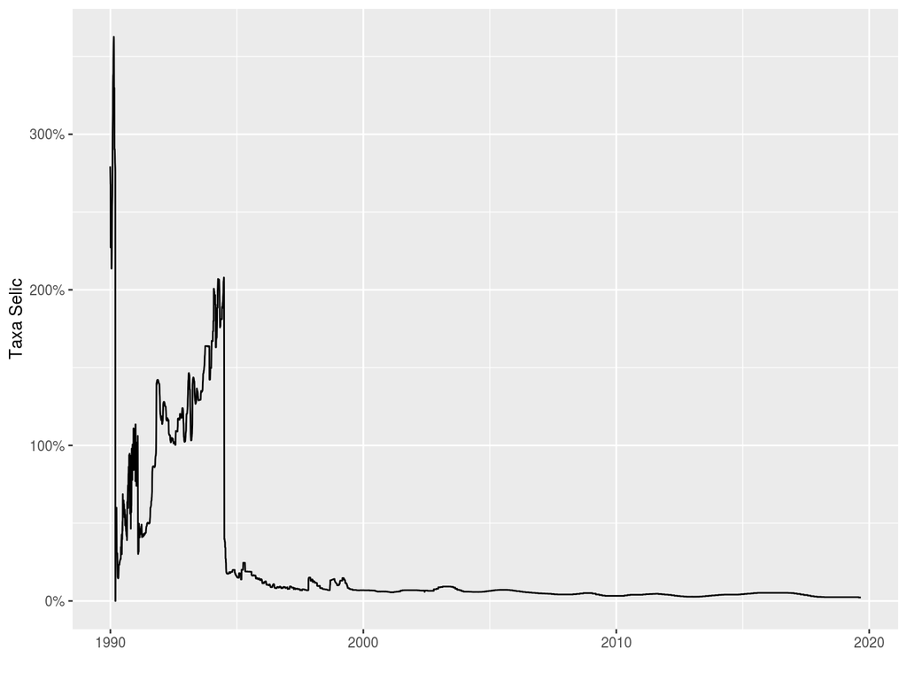

```r
p <- ggplot(df_bcb, aes(x = ref.date, y = value)) +
  geom_line() +
  labs(x = '', y = 'Taxa Selic') +
  scale_y_continuous(labels = scales::percent)
p
```

## Exemplo 2: SELIC e CDI

```r
library(GetBCBData)
library(tidyverse)

my_id <- c('Taxa SELIC' = 11,
           'CDI' = 12)

first_date <- '2000-01-01'
last_date <- Sys.Date()

df_bcb <- gbcbd_get_series(my_id,
                           first.date = first_date,
                           last.date = last_date)

glimpse(df_bcb)
```

```
## Observations: 9,881
## Variables: 4
## $ ref.date    <date> 1999-12-31, 2000-01-03, 2000-01-04, 2000-01-05, 200…
## $ value       <dbl> 0.069186, 0.069186, 0.069186, 0.069220, 0.069286, 0.…
## $ id.num      <dbl> 11, 11, 11, 11, 11, 11, 11, 11, 11, 11, 11, 11, 11, …
## $ series.name <chr> "Taxa SELIC", "Taxa SELIC", "Taxa SELIC", "Taxa SELI…
```

```r
summary(df_bcb)
```

```
##     ref.date              value             id.num     series.name
##  Min.   :1999-12-31   Min.   :0.02275   Min.   :11.0   Length:9881
##  1st Qu.:2004-11-30   1st Qu.:0.03747   1st Qu.:11.0   Class :character
##  Median :2009-10-30   Median :0.04714   Median :11.0   Mode  :character
##  Mean   :2009-10-30   Mean   :0.04884   Mean   :11.5
##  3rd Qu.:2014-09-29   3rd Qu.:0.06032   3rd Qu.:12.0
##  Max.   :2019-09-02   Max.   :0.09285   Max.   :12.0
```

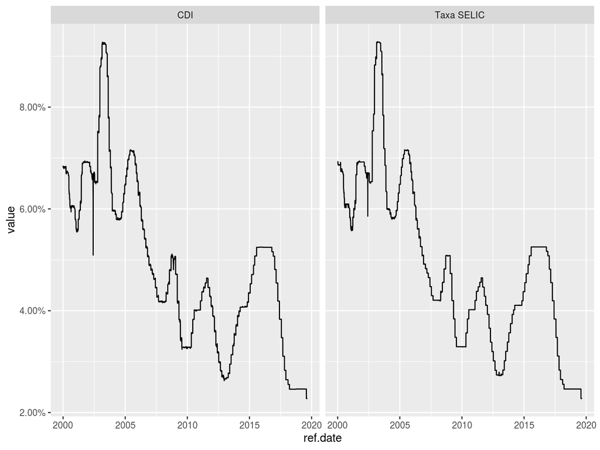

```r
p <- ggplot(df_bcb, aes(x = ref.date, y = value)) +
  geom_line() + facet_wrap(~series.name) +
  scale_y_continuous(labels = scales::percent)

p
```

# Pacote `GetTDData`

**Descrição**

Importa dados de preços e yields (retornos) de títulos públicos negociados no Tesouro Direto

**Fonte**

[Site do Tesouro Direto](http://www.tesouro.fazenda.gov.br/tesouro-direto-balanco-e-estatisticas)

Benefícios: - Baixa, agrega e organiza dados das planilhas

## Exemplo 1: LTN

```r
library(GetTDData)
library(tidyverse)

asset_codes <- 'LTN'   # LFT, LTN, NTN-C, NTN-B, NTN-B Principal, NTN-F
maturity <- '010120'  # Maturity date as string (ddmmyy)

my_flag <- download.TD.data(asset.codes = asset_codes)
df_TD <- read.TD.files(asset.codes = asset_codes, maturity = maturity)
```

```
##
## Reading xls data and saving to data.frame
##  Reading File = TD Files/LTN_2002.xls
##     Cant find maturities in file  TD Files/LTN_2002.xls
##  Reading File = TD Files/LTN_2003.xls
##     Cant find maturities in file  TD Files/LTN_2003.xls
##  Reading File = TD Files/LTN_2004.xls
##     Cant find maturities in file  TD Files/LTN_2004.xls
##  Reading File = TD Files/LTN_2005.xls
##     Cant find maturities in file  TD Files/LTN_2005.xls
##  Reading File = TD Files/LTN_2006.xls
##     Cant find maturities in file  TD Files/LTN_2006.xls
##  Reading File = TD Files/LTN_2007.xls
##     Cant find maturities in file  TD Files/LTN_2007.xls
##  Reading File = TD Files/LTN_2008.xls
##     Cant find maturities in file  TD Files/LTN_2008.xls
##  Reading File = TD Files/LTN_2009.xls
##     Cant find maturities in file  TD Files/LTN_2009.xls
##  Reading File = TD Files/LTN_2010.xls
##     Cant find maturities in file  TD Files/LTN_2010.xls
##  Reading File = TD Files/LTN_2011.xls
##     Cant find maturities in file  TD Files/LTN_2011.xls
##  Reading File = TD Files/LTN_2012.xls
##     Cant find maturities in file  TD Files/LTN_2012.xls
##  Reading File = TD Files/LTN_2013.xls
##     Cant find maturities in file  TD Files/LTN_2013.xls
##  Reading File = TD Files/LTN_2014.xls
##     Cant find maturities in file  TD Files/LTN_2014.xls
##  Reading File = TD Files/LTN_2015.xls
##     Cant find maturities in file  TD Files/LTN_2015.xls
##  Reading File = TD Files/LTN_2016.xls
##     Cant find maturities in file  TD Files/LTN_2016.xls
##  Reading File = TD Files/LTN_2017.xls
##     Reading Sheet LTN 010120
##  Reading File = TD Files/LTN_2018.xls
##     Reading Sheet LTN 010120
##  Reading File = TD Files/LTN_2019.xls
##     Reading Sheet LTN 010120
```

```r
glimpse(df_TD)
```

```
## Observations: 635
## Variables: 5
## $ ref.date   <date> 2017-02-08, 2017-02-09, 2017-02-10, 2017-02-13, 2017…
## $ yield.bid  <dbl> 0.1019, 0.1019, 0.1014, 0.1011, 0.1009, 0.1011, 0.101…
## $ price.bid  <dbl> 756.70, 756.99, 758.27, 759.15, 759.83, 759.73, 759.6…
## $ asset.code <chr> "LTN 010120", "LTN 010120", "LTN 010120", "LTN 010120…
## $ matur.date <date> 2020-01-01, 2020-01-01, 2020-01-01, 2020-01-01, 2020…
```

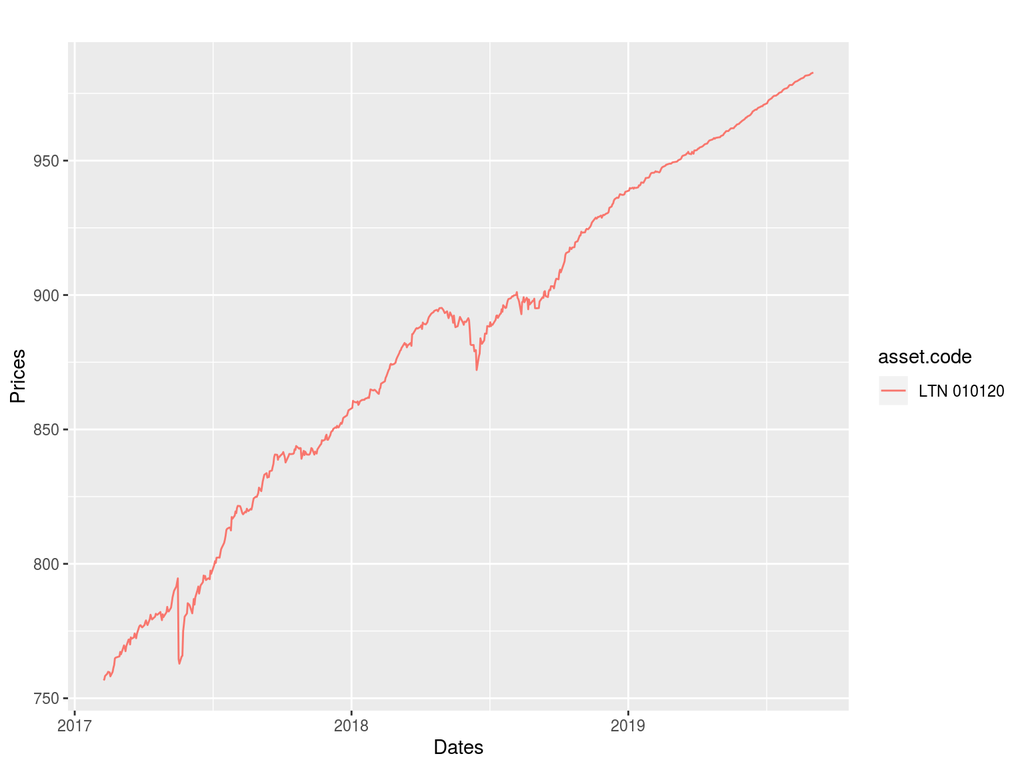

```r
p <- ggplot(data = df_TD,
            aes(x = as.Date(ref.date), y = price.bid, color = asset.code)) +
  geom_line() + scale_x_date() + labs(title = '', x = 'Dates', y = 'Prices' )

print(p)
```

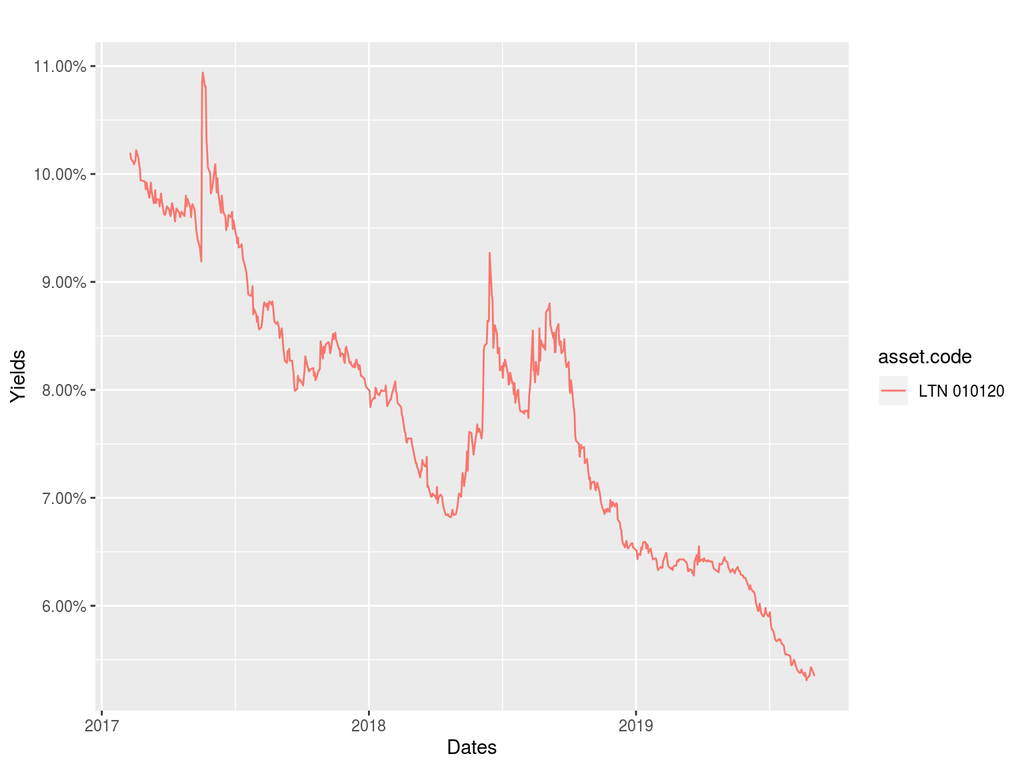

```r
p <- ggplot(data = df_TD, aes(x = as.Date(ref.date), y = yield.bid, color = asset.code)) +
  geom_line() +
  scale_x_date() +
  labs(title = '', x = 'Dates', y = 'Yields' ) +
  scale_y_continuous(labels = scales::percent)

print(p)
```

## Exemplo 2: Diversas LTNs

```r
library(GetTDData)
library(tidyverse)

asset_codes <- 'LTN'   # Identifier of assets
maturity <- NULL  # Maturity date as string (ddmmyy)

my_flag <- download.TD.data(asset.codes = asset_codes)
df_TD <- read.TD.files(asset.codes = asset_codes, maturity = maturity)
```

```
##
## Reading xls data and saving to data.frame
##  Reading File = TD Files/LTN_2002.xls
##     Reading Sheet LTN 070104
##  Reading File = TD Files/LTN_2003.xls
##     Reading Sheet LTN 011003
##     Reading Sheet LTN 070104
##     Reading Sheet LTN 010404
##     Reading Sheet LTN 010704
##     Reading Sheet LTN 011004
##     Reading Sheet LTN 040105
##     Reading Sheet LTN 010705
##  Reading File = TD Files/LTN_2004.xls
##     Reading Sheet LTN 070104
##     Reading Sheet LTN 010404
##     Reading Sheet LTN 010704
##     Reading Sheet LTN 011004
##     Reading Sheet LTN 040105
##     Reading Sheet LTN 010405
##     Reading Sheet LTN 010705
##     Reading Sheet LTN 011005
##     Reading Sheet LTN 010106
##     Reading Sheet LTN 010706
##  Reading File = TD Files/LTN_2005.xls
##     Reading Sheet LTN 040105
##     Reading Sheet LTN 010405
##     Reading Sheet LTN 010705
##     Reading Sheet LTN 011005
##     Reading Sheet LTN 010106
##     Reading Sheet LTN 010406
##     Reading Sheet LTN 010706
##     Reading Sheet LTN 011006
##     Reading Sheet LTN 010107
##     Reading Sheet LTN 010407
##     Reading Sheet LTN 010707
##     Reading Sheet LTN 010108
##     Reading Sheet LTN 010708
##  Reading File = TD Files/LTN_2006.xls
##     Reading Sheet LTN 010406
##     Reading Sheet LTN 010706
##     Reading Sheet LTN 011006
##     Reading Sheet LTN 010107
##     Reading Sheet LTN 010407
##     Reading Sheet LTN 010707
##     Reading Sheet LTN 011007
##     Reading Sheet LTN 010108
##     Reading Sheet LTN 010408
##     Reading Sheet LTN 010708
##     Reading Sheet LTN 010109
##  Reading File = TD Files/LTN_2007.xls
##     Reading Sheet LTN 010407
##     Reading Sheet LTN 010707
##     Reading Sheet LTN 011007
##     Reading Sheet LTN 010108
##     Reading Sheet LTN 010408
##     Reading Sheet LTN 010708
##     Reading Sheet LTN 011008
##     Reading Sheet LTN 010109
##     Reading Sheet LTN 010709
##     Reading Sheet LTN 011009
##     Reading Sheet LTN 010110
##  Reading File = TD Files/LTN_2008.xls
```

```
##     Reading Sheet LTN 010408
```

```
##     Reading Sheet LTN 010708
```

```
##     Reading Sheet LTN 011008
##     Reading Sheet LTN 010109
##     Reading Sheet LTN 010409
##     Reading Sheet LTN 010709
##     Reading Sheet LTN 011009
##     Reading Sheet LTN 010110
##     Reading Sheet LTN 010710
##     Reading Sheet LTN 010111
##  Reading File = TD Files/LTN_2009.xls
##     Reading Sheet LTN 010409
##     Reading Sheet LTN 010709
##     Reading Sheet LTN 011009
##     Reading Sheet LTN 010110
##     Reading Sheet LTN 010710
##     Reading Sheet LTN 010111
##     Reading Sheet LTN 010112
##  Reading File = TD Files/LTN_2010.xls
##     Reading Sheet LTN 010710
##     Reading Sheet LTN 010111
##     Reading Sheet LTN 010711
##     Reading Sheet LTN 010112
##     Reading Sheet LTN 010113
##  Reading File = TD Files/LTN_2011.xls
##     Reading Sheet LTN 010711
##     Reading Sheet LTN 010112
##     Reading Sheet LTN 010113
##     Reading Sheet LTN 010114
##     Reading Sheet LTN 010115
##  Reading File = TD Files/LTN_2012.xls
##     Reading Sheet LTN 010113
##     Reading Sheet LTN 010114
##     Reading Sheet LTN 010115
##     Reading Sheet LTN 010116
##  Reading File = TD Files/LTN_2013.xls
##     Reading Sheet LTN 010114
##     Reading Sheet LTN 010115
##     Reading Sheet LTN 010116
##     Reading Sheet LTN 010117
##  Reading File = TD Files/LTN_2014.xls
##     Reading Sheet LTN 010115
```

[output cut: 17 more lines]

```
##     Reading Sheet LTN 010120
##     Reading Sheet LTN 010121
##     Reading Sheet LTN 010123
##  Reading File = TD Files/LTN_2018.xls
##     Reading Sheet LTN 010119
##     Reading Sheet LTN 010120
##     Reading Sheet LTN 010121
##     Reading Sheet LTN 010123
##     Reading Sheet LTN 010125
##  Reading File = TD Files/LTN_2019.xls
##     Reading Sheet LTN 010120
##     Reading Sheet LTN 010121
##     Reading Sheet LTN 010122
##     Reading Sheet LTN 010123
##     Reading Sheet LTN 010125
```

```r
glimpse(df_TD)
```

```
## Observations: 21,889
## Variables: 5
## $ ref.date   <date> 2002-03-18, 2002-03-19, 2002-03-20, 2002-03-21, 2002…
## $ yield.bid  <dbl> 0.1977, 0.1975, 0.1967, 0.2005, 0.1983, 0.1996, 0.198…
## $ price.bid  <dbl> 720.96, 721.70, 723.09, 719.48, 722.38, 721.49, 723.3…
## $ asset.code <chr> "LTN 070104", "LTN 070104", "LTN 070104", "LTN 070104…
## $ matur.date <date> 2004-01-07, 2004-01-07, 2004-01-07, 2004-01-07, 2004…
```

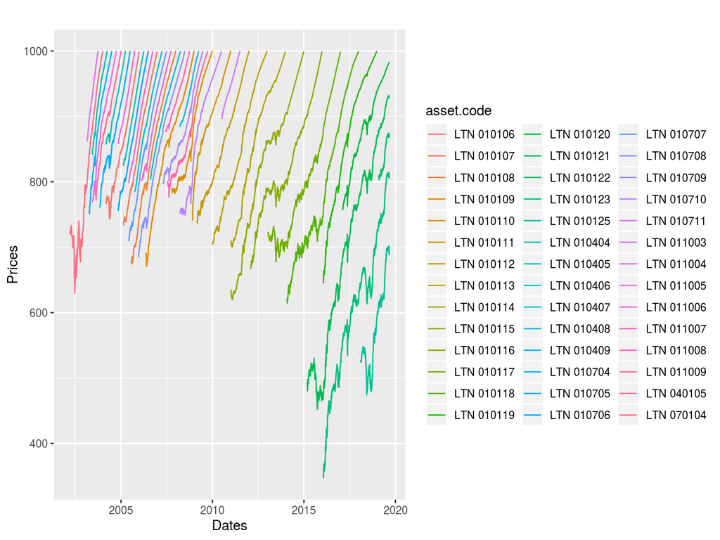

```r
p <- ggplot(data = df_TD,
            aes(x = as.Date(ref.date), y = price.bid, color = asset.code)) +
  geom_line() + scale_x_date() + labs(title = '', x = 'Dates', y = 'Prices' )

print(p)
```

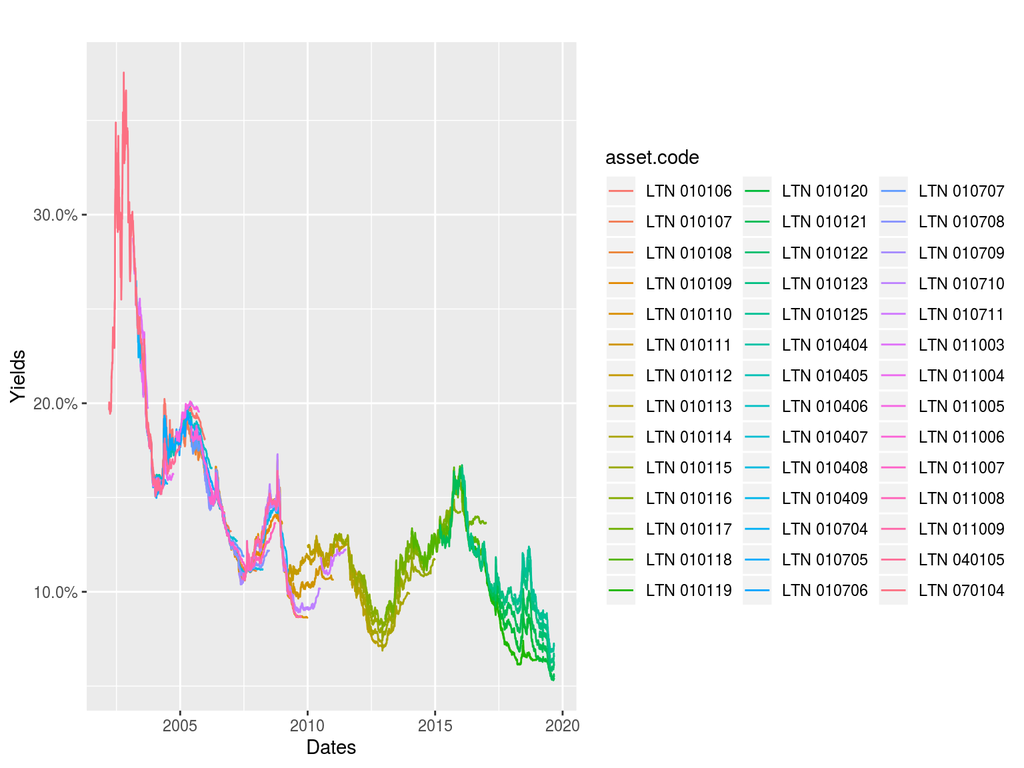

```r
p <- ggplot(data = df_TD, aes(x = as.Date(ref.date), y = yield.bid, color = asset.code)) +
  geom_line() +
  scale_x_date() +
  labs(title = '', x = 'Dates', y = 'Yields' ) +
  scale_y_continuous(labels = scales::percent)

print(p)
```

# Pacote `GetHFData`

**Descrição**

Projetado para facilitar a importação e análise de dados de negociação e ordens na alta frequência (*tick by tick*) na B3. Paper com detalhes sobre implementação na [RBFin](http://bibliotecadigital.fgv.br/ojs/index.php/rbfin/article/view/64587/65702).

**Fonte**

ftp público da b3 (até 31/11/2019, infelizmente)

## Exemplo 1: PETR4 e GGBR4

```r
library(GetHFData)

# get available dates
df_ftp <- ghfd_get_ftp_contents(type.market = 'equity')
```

```
##
## Reading ftp contents for equity(trades) (attempt = 1|10)
```

```r
last_date <- last(df_ftp$dates)
first_date <- df_ftp$dates[nrow(df_ftp) - 1]

# set tickers and type of market
my.assets <- c('PETR4', 'GGBR4')
type.market <- 'equity' #  'equity', 'equity-odds','options', 'BMF'
type.data <- 'trades' # trades or orders
type.output <- 'agg' # 'agg', 'raw'
agg.diff <- '15 min'

# get data!
df_trades_agg <- ghfd_get_HF_data(my.assets = my.assets,
                          type.market = type.market,
                          type.data = type.data,
                          first.date = first_date,
                          last.date = last_date,
                          first.time = '10:00:00',
                          last.time = '17:00:00',
                          type.output = type.output,
                          agg.diff = agg.diff )
```

```
##
## Running ghfd_get_HF_Data for:
##    type.market = equity
##    type.data = trades
##    my.assets = PETR4 GGBR4
##    type.output = agg
##       agg.diff = 15 min
## Reading ftp contents for equity(trades) (attempt = 1|10) - Error in reading ftp contents. Trying again..
## Reading ftp contents for equity(trades) (attempt = 2|10)
##    Found  125  files in ftp
##    First available date in ftp:  2019-02-28
##    Last available date in ftp:   2019-08-29
##    First date to download:  2019-08-28
##    Last date to download:   2019-08-29
##    -> Reading files - Imported  1539074 lines, 530 unique tickers
##    -> Processing file - Found 71491 lines for 2 selected tickers
##    -> Aggregation resulted in dataframe with 56 rows
##    -> Reading files - Imported  1821853 lines, 547 unique tickers
##    -> Processing file - Found 86954 lines for 2 selected tickers
##    -> Aggregation resulted in dataframe with 56 rows
```

```r
# print results
dplyr::glimpse(df_trades_agg)
```

```
## Observations: 112
## Variables: 13
## $ InstrumentSymbol <chr> "GGBR4", "GGBR4", "GGBR4", "GGBR4", "GGBR4", "G…
## $ SessionDate      <date> 2019-08-28, 2019-08-28, 2019-08-28, 2019-08-28…
## $ TradeDateTime    <dttm> 2019-08-28 10:00:00, 2019-08-28 10:15:00, 2019…
## $ n.trades         <int> 742, 306, 572, 621, 427, 368, 421, 281, 492, 35…
## $ last.price       <dbl> 11.64, 11.63, 11.71, 11.81, 11.78, 11.78, 11.81…
## $ weighted.price   <dbl> 11.62724, 11.62532, 11.67064, 11.75255, 11.8058…
## $ period.ret       <dbl> -0.0034246575, -0.0008591065, 0.0051502146, 0.0…
## $ period.ret.volat <dbl> 0.0004640695, 0.0006410306, 0.0005234813, 0.000…
## $ sum.qtd          <dbl> 677400, 371100, 546300, 465300, 229100, 258200,…
## $ sum.vol          <dbl> 7876215, 4314140, 6375635, 5468415, 2704708, 30…
## $ n.buys           <int> 320, 153, 320, 403, 198, 162, 223, 117, 226, 25…
## $ n.sells          <int> 422, 153, 252, 218, 229, 206, 198, 164, 266, 10…
## $ Tradetime        <chr> "10:00:00", "10:15:00", "10:30:00", "10:45:00",…
```

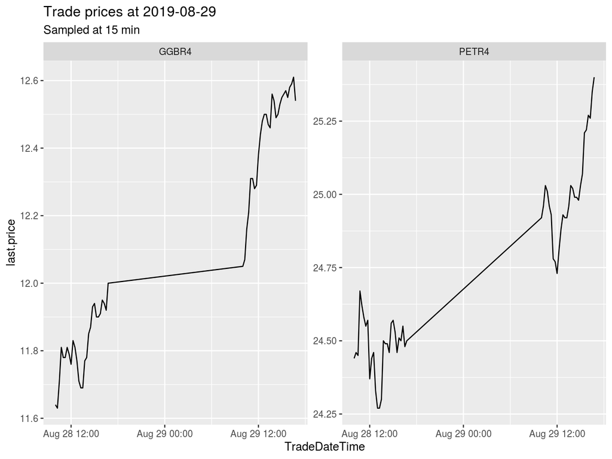

```r
library(ggplot2)

print(ggplot(data = na.omit(df_trades_agg),
             aes(x = TradeDateTime, y = last.price)) +
        geom_line() +
        facet_wrap(~InstrumentSymbol, scales = 'free') +
        labs(title = paste0('Trade prices at ', last_date),
             subtitle = paste0('Sampled at ', agg.diff)) )
```

## Exemplo 2: Dados brutos (*tick by tick*)

```r
library(GetHFData)

# set tickers and type of market
my.assets <- c('PETR4', 'GGBR4')
type.market <- 'equity' #  'equity', 'equity-odds','options', 'BMF'
type.data <- 'trades' # trades or orders
type.output <- 'raw' # 'agg', 'raw'

# get data!
df_trades_raw <- ghfd_get_HF_data(my.assets = my.assets,
                          type.market = type.market,
                          type.data = type.data,
                          first.date = first_date,
                          last.date = last_date,
                          first.time = '10:00:00',
                          last.time = '17:00:00',
                          type.output = type.output,
                          agg.diff = agg.diff )
```

```
##
## Running ghfd_get_HF_Data for:
##    type.market = equity
##    type.data = trades
##    my.assets = PETR4 GGBR4
##    type.output = raw
## Reading ftp contents for equity(trades) (attempt = 1|10)
##    Found  125  files in ftp
##    First available date in ftp:  2019-02-28
##    Last available date in ftp:   2019-08-29
##    First date to download:  2019-08-28
##    Last date to download:   2019-08-29
##    -> Reading files - Imported  1539074 lines, 530 unique tickers
##    -> Processing file - Found 71491 lines for 2 selected tickers
##    -> Reading files - Imported  1821853 lines, 547 unique tickers
##    -> Processing file - Found 86954 lines for 2 selected tickers
```

```r
# print results
dplyr::glimpse(df_trades_raw)
```

```
## Observations: 156,539
## Variables: 10
## $ SessionDate         <date> 2019-08-28, 2019-08-28, 2019-08-28, 2019-08…
## $ InstrumentSymbol    <chr> "GGBR4", "GGBR4", "GGBR4", "GGBR4", "GGBR4",…
## $ TradePrice          <dbl> 11.68, 11.68, 11.68, 11.68, 11.68, 11.68, 11…
## $ TradedQuantity      <dbl> 100, 500, 300, 100, 100, 100, 900, 100, 100,…
## $ Tradetime           <chr> "10:03:00.000", "10:03:00.000", "10:03:00.00…
## $ CrossTradeIndicator <int> 0, 0, 0, 0, 0, 0, 0, 0, 0, 0, 0, 0, 0, 0, 0,…
## $ BuyMember           <dbl> 3, 72, 72, 27, 21, 3, 114, 114, 23, 308, 308…
## $ SellMember          <dbl> 147, 147, 15, 15, 15, 15, 15, 147, 147, 147,…
## $ TradeDateTime       <dttm> 2019-08-28 10:03:00, 2019-08-28 10:03:00, 2…
## $ TradeSign           <dbl> -1, -1, -1, -1, -1, -1, -1, -1, -1, -1, -1, …
```

[figure not shown]

# Pacote `GetDFPData`

**Descrição**

Interface aberta para todas as demonstrações financeiras distribuídas pela B3 e pela CVM nos sistemas DFP, FRE e FCA. Versão web disponível em http://www.msperlin.com/shiny/GetDFPData/.

**Fonte**

Sistemas DFP, FRE e FCA da B3

## Exemplo 1: Dados da AMBEV

```r
library(GetDFPData)

df.info <- gdfpd.get.info.companies(type.data = 'companies')
```

```
## Found cache file. Loading data..
```

```r
dplyr::glimpse(df.info)
```

```
## Observations: 528
## Variables: 16
## $ name.company         <chr> "521 PARTICIPAÇOES S.A. - EM LIQUIDAÇÃO EXT…
## $ id.company           <int> 16330, 16284, 21725, 18970, 22179, 24643, 2…
## $ cnpj                 <dbl> 1.547749e+12, 1.851771e+12, 1.034501e+13, 4…
## $ date.registration    <date> 1997-07-11, 1997-05-30, 2009-06-24, 2001-0…
## $ date.constitution    <date> 1996-07-30, 1997-04-02, 2008-08-18, 2000-1…
## $ city                 <chr> "RIO DE JANEIRO", "RIO DE JANEIRO", "SÃO PA…
## $ estate               <chr> "RJ", "RJ", "SP", "SP", "RJ", "SP", "SP", N…
## $ situation            <chr> "ATIVO", "ATIVO", "ATIVO", "ATIVO", "ATIVO"…
## $ situation.operations <chr> "LIQUIDAÇÃO EXTRAJUDICIAL", "FASE OPERACION…
## $ listing.segment      <chr> NA, "Tradicional", "Tradicional", "Corporat…
## $ main.sector          <chr> NA, "Outros", "Saúde", "Utilidade Pública",…
## $ sub.sector           <chr> NA, "Outros", "Serv.Méd.Hospit..Análises e …
## $ segment              <chr> NA, "Outros", "Serv.Méd.Hospit..Análises e …
## $ tickers              <chr> NA, "QVQP3B", "ADHM3", "TIET11;TIET3;TIET4"…
## $ first.date           <date> 1998-12-31, 2001-12-31, 2008-12-31, 2001-1…
## $ last.date            <date> 2018-12-31, 2018-12-31, 2018-12-31, 2018-1…
```

Toda empresa no banco de dados pode ser identificada pelo seu nome oficial ou identificação numérica da CVM. Função `gdfpd.search.company` permite que o usuário procure o nome oficial da empresa.

```r
gdfpd.search.company('ambev')
```

```
## Found cache file. Loading data..
##
## Found 1 companies:
## AMBEV S.A. | situation = ATIVO | first date = 2012-12-31 | last date - 2018-12-31
```

```
## [1] "AMBEV S.A."
```

Usamos a função principal do pacote, `gdfpd.GetDFPData`, para baixar informações.

```r
library(GetDFPData)

# set options
name.companies <- 'AMBEV S.A.'
first.date <- '2015-12-31'
last.date  <- '2017-12-31'

# download data
df.reports <- gdfpd.GetDFPData(name.companies = name.companies,
                               first.date = first.date,
                               last.date = last.date)
```

```
## Found cache file. Loading data..
##
## First Date: 2015-12-31
## Laste Date: 2017-12-31
## Inflation index: dollar
##
##  Caching inflation RDATA into tempdir()  Done
##
## Inputs looking good! Starting download of files:
##
## AMBEV S.A.
##  Available periods: 2017-12-31   2016-12-31  2015-12-31
##
##
## Processing 23264 - AMBEV S.A.
##  Finding info from Bovespa
##      Found BOV cache file
##  Processing 23264 - AMBEV S.A. | date 2017-12-31
##      Acessing DFP data | Found DFP cache file
##      Acessing FRE data | Found FRE cache file
##      Acessing FCA data | Found FCA cache file
##  Processing 23264 - AMBEV S.A. | date 2016-12-31
##      Acessing DFP data | Found DFP cache file
##      Acessing FRE data | Found FRE cache file
##      Acessing FCA data | Found FCA cache file
##  Processing 23264 - AMBEV S.A. | date 2015-12-31
##      Acessing DFP data | Found DFP cache file
##      Acessing FRE data | Found FRE cache file
##      Acessing FCA data | Found FCA cache file
```

```r
glimpse(df.reports)
```

```
## Observations: 1
## Variables: 46
## $ company.name                     <chr> "AMBEV S.A."
## $ company.code                     <int> 23264
## $ cnpj                             <chr> "07526557000100"
## $ date.company.constitution        <date> 2005-07-08
## $ date.cvm.registration            <date> 2013-10-30
## $ company.tickers                  <chr> "ABEV3"
## $ min.date                         <date> 2015-12-31
## $ max.date                         <date> 2017-12-31
## $ n.periods                        <int> 3
## $ company.segment                  <chr> "Tradicional"
## $ current.stockholders             <list> [<data.frame[6 x 6]>]
## $ current.stock.composition        <list> [<data.frame[3 x 4]>]
## $ history.files                    <list> [<data.frame[1 x 2]>]
```

[output cut: 33 more lines]

Vamos dar uma olhada no balanço patrimonial da empresa, disponível em `df.reports$fr.assets[[1]]`:

```r
# save assets in df
fr.assets <- df.reports$fr.assets[[1]]

# check it
glimpse(fr.assets)
```

```
## Observations: 48
## Variables: 6
## $ name.company       <chr> "AMBEV S.A.", "AMBEV S.A.", "AMBEV S.A.", "AM…
## $ ref.date           <date> 2017-12-31, 2017-12-31, 2017-12-31, 2017-12-…
## $ acc.number         <chr> "1", "1.01", "1.01.01", "1.01.02", "1.01.03",…
## $ acc.desc           <chr> "Ativo Total", "Ativo Circulante", "Caixa e E…
## $ acc.value          <dbl> 91568737, 11272513, 2017034, 631637, 3055953,…
## $ acc.value.infl.adj <dbl> 27686018.32, 3408270.24, 609854.87, 190976.90…
```

# Exemplo prático do ciclo de pesquisa